# Lab 054 · TabM & parameter-efficient ensembling

Lesson · Reference

**Skill:** implement corrected v2 numeric TabM-mini (shared backbone weights AND biases; only first R; independent heads) and compare four deployment procedures — a single MLP, a deep ensemble MLP×k, TabM-mini, and tuned XGBoost — while measuring the collective-versus-individual submodel effect. **Scope:** numeric forward path only; no feature embeddings or categorical inputs, and not the paper's 46-dataset benchmark. Four TODO functions feed the visible model and training code. PROVIDED = read/run; CHECK = immediate diagnostic feedback; EXIT = explain your result.

**Reproducibility contract:** real California Housing, House 16H and Higgs Small data from the TabR release inherited by the TabM benchmark (Appendix C); capped here and not independently compared with a second TabM archive. Preserve released boundaries; label-blind row caps 1200/600/600, selection seeds 53/54/55; model seeds 0/1/2. z-score statistics fit on training rows only. TabM-mini: width 64, depth 3, k=32, 64 epochs, batch 256, Adam. **INCOMPARABLE** to the paper benchmark. See contract.

**Note on runtime:** the deep ensemble trains k separate MLPs, so a full k=32 / 3-seed run takes ~20 CPU minutes. This notebook's live cell uses a lighter default (3 seeds, k=8, 32 epochs); the author evidence in the figures used k=32 and three seeds.

### Running on Google Colab?

Colab opens only this single file, so the course package (`relkit`) and the lab dependencies (xgboost, lightgbm, catboost, …) are **not** present by default. The cell below fixes that: on Colab it shallow-clones the course repo, installs `requirements-labs.txt`, and switches into `labs/` so `relkit` imports and the data cache resolve. **On a local venv or your own Jupyter it does nothing — just run it and continue.**

```python
# @colab-bootstrap — PROVIDED. Makes the lab self-sufficient on Google Colab; a no-op elsewhere.
import os, sys

if "google.colab" in sys.modules:
    if not os.path.isdir("/content/relational"):
        !git clone --depth 1 https://github.com/Avistian/relational.git /content/relational
    %pip install -q -r /content/relational/requirements-labs.txt
    os.chdir("/content/relational/labs")
    print("Colab ready — working dir:", os.getcwd())
else:
    print("Not on Colab — using the local environment as-is.")
```

```python
# PROVIDED — runtime and data setup
import os, sys, copy, math, hashlib, json, time, importlib.metadata
from pathlib import Path
os.environ['OMP_NUM_THREADS'] = '1'; os.environ['OPENBLAS_NUM_THREADS'] = '1'
os.environ.setdefault('MPLCONFIGDIR', '/tmp/relational-matplotlib')
import numpy as np
import torch
from torch import nn
from torch.utils.data import DataLoader, TensorDataset
import pandas as pd
import matplotlib.pyplot as plt
from IPython.display import display
from scipy.stats import rankdata, friedmanchisquare, studentized_range
from threadpoolctl import threadpool_limits
from xgboost import XGBClassifier, XGBRegressor
torch.set_num_threads(1)
for candidate in (Path.cwd(), Path.cwd() / 'labs', Path.cwd().parent):
    if (candidate / 'relkit').is_dir():
        LABS = candidate.resolve(); os.chdir(LABS); sys.path.insert(0, str(LABS)); break
else:
    raise RuntimeError('Use the Colab bootstrap or run inside this repository')
from _fetch_l052 import fetch
from relkit.tabr_experiment import seed_interval
from relkit.realmlp_experiment import load_task, error, fit_trees, SEARCH
fetch()
print({p: importlib.metadata.version(p) for p in ['torch', 'numpy', 'scipy', 'scikit-learn', 'xgboost']})
print('Data manifest SHA256', hashlib.sha256((LABS / '_data_l052.json').read_bytes()).hexdigest())
```

## 1. Ensembling: averaging several predictors

**Start with the familiar version.** A **deep ensemble** is a set of networks that are each trained separately, with a different random seed, whose predictions are then averaged. Why would averaging help at all? It helps only when the members make *complementary* errors — mistakes that partly cancel when you average them. So the ensemble need not beat its single best member, and averaging two copies of the same model changes nothing. The cost is blunt: storing k independent networks takes about k times the parameters of one network, and training them repeats the whole optimization.

**In plain terms.** Averaging helps for the same reason a panel of judges can beat one judge: only if the judges are wrong in different ways. Cloning one judge adds no wisdom, just cost.

**Now the cheaper version.** **Parameter-efficient ensembling** keeps the large matrices shared across members, and gives each member only a small set of its own parameters plus its own output head. TabM builds on an existing technique called BatchEnsemble, and it changes how that technique shares weights and how it initializes them. The saving is a saving in *parameters* first of all. The activations still carry a member axis, and the dense multiply-adds still scale with k, so compute does not shrink the same way.

**Scope check.** Runtime overhead can be less than k on hardware that the original MLP underuses; this is a measurement, not a guarantee of nearly free inference. [Paper §3.2](https://arxiv.org/html/2410.24210v3#S3.SS2) and [Appendix A.1](https://arxiv.org/html/2410.24210v3#A1.SS1).

**Two levers, kept separate.** The paper varies two things that are easy to confuse. **Weight sharing** is a constraint on the model: it limits which functions the members can represent. **Ensemble-aware selection** is a choice made during tuning: it picks the hyperparameters and the stopping epoch using the *average* prediction's validation metric, not each member's own metric. The paper's architecture ladder is designed to probe both levers, one at a time. Our smaller four-arm experiment changes several things at once, so it cannot single out either lever as the unique cause of an improvement.

### Why averaging helps only some kinds of error

Write member i's regression prediction as the true conditional mean plus an error eᵢ. The ensemble error is the average of those errors. If each member has error variance σ² and every pair has correlation ρ, the variance of the k-member average is σ²[ρ+(1−ρ)/k]. This follows by expanding the variance of a sum into k variance terms and k(k−1) covariance terms. The widget and fixed-correlation k→∞ discussion restrict ρ to [0,1]; negative equal pairwise correlations must satisfy ρ≥−1/(k−1) and cannot stay fixed negative as k grows.

For k=4 and ρ=0, the variance is σ²/4. For ρ=0.75 it is 0.8125σ². Adding members cannot average away the shared component. As k grows, the expression approaches ρσ², not zero. The calculation assumes equal variances and equal pairwise correlation; use it as intuition rather than a fitted law for every TabM ensemble.

Bias matters as well. If every member makes the same systematic mistake, averaging preserves it. “Diversity” is useful when different predictions contain complementary information about the target. Randomly making a strong predictor worse can increase disagreement without improving the ensemble.

TabM aims to obtain useful diversity with shared expensive matrices and relatively cheap member-specific parameters. This creates a tension: sharing reduces parameter storage and can couple learning beneficially, but it also prevents members from being independent fits. The experiment should measure the collective result, individual members and cost rather than assuming independence from the member count.

### Three axes that a single ensemble score hides

Separate member quality, error dependence and aggregation. A weak member may help if its useful errors differ from the rest; a strong but redundant member may add little. The aggregation rule can also change the result even with identical members. Inspect these axes before interpreting why the ensemble improved or failed.

## 2. Model architecture

### The symbols, once

Fix the notation before the mechanics. The pictured model is **numeric TabM-mini, corrected v2**, with shared training batches (the paper's §3.4 simplification). B is the number of rows in a batch. p is the number of numeric features. k is the number of members. d is the hidden width. N is the number of blocks. dy is the output width (1 for regression, 2 for our binary tasks). Median imputation and z-score statistics are fitted only on training rows. Regression targets are standardized on training rows, and the errors are converted back to their original units for reporting.

**In plain terms.** One row of features fans out into k slightly different copies. Each copy travels through the same shared network but with its own small adjustments, and at the very end the k answers are averaged into one.

### The forward path, step by step

**Broadcast the row.** Take x with shape [B,p] and copy it to shape [B,k,p], one copy per member.

**Give each member its own adapter.** Multiply by the learned input adapter R₁:[k,p], initialized to random ±1. Those entries are **continuous trainable scalars after initialization**, not permanently binary masks; the ±1 is only the starting value.

**Pass through the shared backbone.** Then repeat N blocks. Each block is a shared linear transformation with a **shared bias**, then ReLU max(0,h), then dropout. Dropout independently masks activations during training and is disabled at inference. Mini is deliberately minimal: it has **no S adapter anywhere, no later R, and no member-specific backbone bias**.

**Split into member heads.** The remaining outputs [B,k,d] pass through k independent heads [k,d,dy], one head per member.

**Aggregate.** For classification, softmax each member's dy logits and average the probabilities over k. For regression, average the scalar outputs. The labels reach a mean-of-member-losses objective during training; they are never input features. Member differences can come from the independent heads, the input adapters, and training randomness together — the first adapter is not their only possible source.

### What the full TabM adds

Full **TabM** keeps input/output scaling vectors R,S and member biases in every block, not only at the input. All multiplicative adapters except R₁ start at 1; member bias rows start equal to an ordinary random linear bias. They can then diverge while learning. The paper's † variants apply numerical feature embeddings *before* the backbone; Appendix A.2 uses a normal first-adapter initialization for those variants. Our plain-numeric scope excludes embeddings, one-hot categories and multiclass training. [§3.3, Figure 1](https://arxiv.org/html/2410.24210v3#S3.SS3), [A.2](https://arxiv.org/html/2410.24210v3#A1.SS2).

### Count the parameter saving

**Worked example.** Fix p=8, d=64, N=3, a scalar output and k=32. The shared backbone has (8×64+64)+2(64×64+64)=8,896 parameters. One MLP adds 65 head parameters, for 8,961. The corrected mini adds 32×8 input scales and 32×65 head parameters, for 11,232 total. An independent MLP×32 stores 286,752 parameters. So mini is about 1.25 times one MLP, and 3.9% of the independent ensemble's parameter count in this example. But its hidden activations still have shape[B,32,64], so this arithmetic establishes storage savings, not equivalent runtime or activation memory.

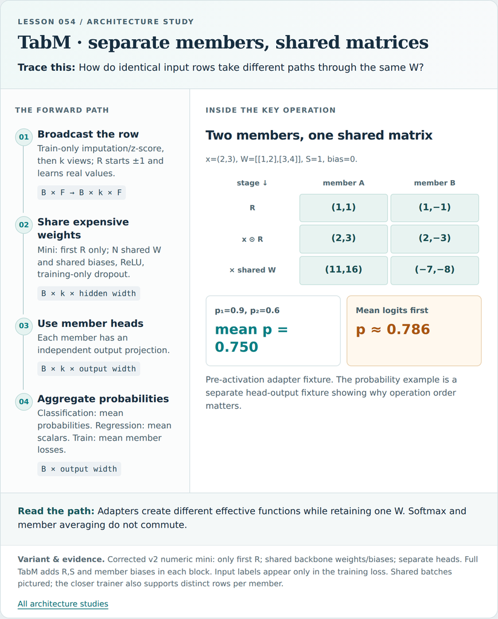

*Portable architecture figure. On a narrow notebook screen, scroll horizontally to retain readable labels.* [Open the responsive diagram](https://avistian.github.io/relational/labs/html/architecture-review/0054-tabm.html).

**Read the path:** Adapters create different effective functions while retaining one W. Softmax and member averaging do not commute.

**Variant and evidence:** Corrected v2 numeric mini: only first R; shared backbone weights/biases; separate heads. Full TabM adds R,S and member biases in each block. Input labels appear only in the training loss. Shared batches pictured; the closer trainer also supports distinct rows per member.

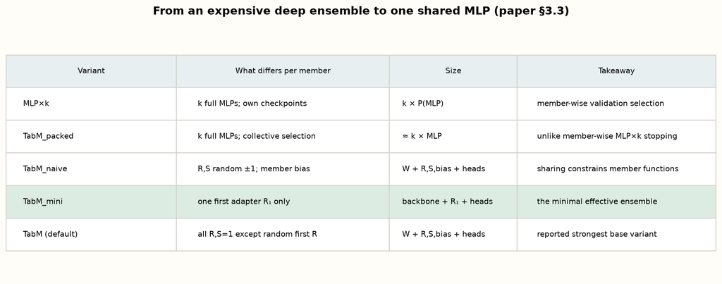

The variant ladder from an explicit deep ensemble down to one shared MLP. We build TabM-mini. On narrow screens, scroll to read labels. Open full-size figure.

## 3. The BatchEnsemble layer

The system view shows several member paths through a shared backbone. Now open one layer: multiplying inputs by member-specific vectors changes each effective function while retaining a common matrix. This is the computational source of the efficiency claim.

**The goal of the layer.** The BatchEnsemble layer is what produces several members from one shared matrix. Start from any linear layer *l(x) = Wx + b*. A deep ensemble would give member *i* its own full matrix *Wᵢ*. BatchEnsemble refuses that cost. It keeps one shared *W* and gives member *i* only three small **adapters**: a multiplicative vector *rᵢ* applied to the input, a multiplicative vector *sᵢ* applied to the output, and an additive bias *bᵢ*. The member then computes [(§3.2)](https://arxiv.org/html/2410.24210v3#S3.SS2):

`lᵢ(x) = sᵢ ⊙ ( W ( rᵢ ⊙ x ) ) + bᵢ` which equals giving member *i* the matrix `Wᵢ = W ⊙ ( sᵢ rᵢᵀ )`.

**In plain terms.** Instead of storing a whole new matrix for each member, you store one matrix plus a couple of short lists of dials per member. The dials stretch or flip the rows and columns of the shared matrix, so each member effectively uses a slightly different matrix while the expensive part stays shared.

**Reading the symbols.** Here ⊙ is coordinate-wise multiplication. The term *sᵢ rᵢᵀ* is the **outer product**: a rank-one matrix whose (o,i) entry is sᵢ[o]·rᵢ[i]. So each member reuses the shared *W* but rescales its rows and columns by learned scalar factors, which equal ±1 only at initialization. Adding a member costs only *3d* new numbers per layer, which is small beside *W*'s *d²* when d is large.

**How TabM differs from the original.** Original BatchEnsemble initializes its multiplicative adapters randomly with ±1. Full TabM instead initializes only the first R randomly; mini retains only that R. Stacked over members, the layer runs all *k* in parallel: `l_BE(X) = ((X ⊙ R) W) ⊙ S + B` with *X* of shape [k, d]. [Source: §3.2.](https://arxiv.org/html/2410.24210v3#S3.SS2)

### Two matrix conventions, one operation

The same operation appears in two layouts, which is a common source of confusion. The paper's single-object equation uses column vectors and W:[dout,din], so its mask is srᵀ. The notebook stores the transpose W:[din,dout] and multiplies row vectors on the right, so its mask is rsᵀ. When W is rectangular, these shapes expose a mistaken transpose immediately, which makes it a useful check. One more caution: the figure of 3d added parameters per member, for width d, describes a *full BatchEnsemble layer*, not mini's single input adapter.

A subtle point about rank. The multiplier rsᵀ has rank one. But W⊙(rsᵀ)=diag(r)Wdiag(s) generally has the same rank as W whenever the scaling entries are nonzero. So this is multiplicative row/column scaling, which is unlike adding a low-rank LoRA update. It cannot freely move one matrix entry without coupling an entire row or column.

### Follow two members through one shared matrix

Use row-vector convention. Let x=(2,3), shared W=[[1,2],[3,4]], zero bias and output adapters S=(1,1). Member A has input adapter Rₐ=(1,1); member B has Rᵦ=(1,−1). A sends (2,3) into W and obtains (11,16). B sends (2,−3) into the same W and obtains (−7,−8). The matrix is shared; the effective function differs.

In this convention, member i's effective matrix entry is Rᵢ,a Wₐ,b Sᵢ,b. The adapter multiplies an entire input direction and an entire output direction. It cannot independently choose every entry of a dense matrix. Calling the adapter a low-rank multiplicative modulation does not mean that the resulting effective matrix must itself have low rank.

For width d on both sides, the shared matrix uses d² parameters. A full BatchEnsemble layer adds roughly k(2d+d) parameters when both multiplicative adapters and member biases are included. Independent dense layers instead use about k(d²+d). At large d, sharing the d² term can save substantial storage. Activations still carry a member axis, so compute and activation memory do not become independent of k.

Corrected v2 mini keeps only the first input adapter R, ordinary shared backbone biases, and independent output heads. It has no S adapter or member-specific backbone biases. The preserved v1 operator included those extra parameters and is historical evidence, not this architecture. The full local TabM variant uses adapters through the backbone. These variants must not be conflated in an architecture caption: their sharing patterns are different.

The first random sign adapter breaks member symmetry. Later adapters initialized to one initially preserve the shared transformation. If every member had identical parameters, identical inputs and identical stochastic behavior, gradient updates would have no reason to separate them. The initialization is therefore a load-bearing part of the ensemble construction.

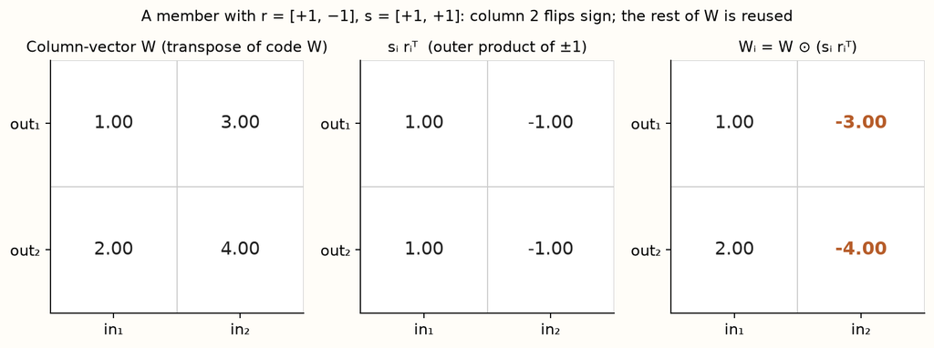

A member reuses the shared W with a rank-one ±1 mask; here column 2 flips sign. On narrow screens, scroll to read labels. Open full-size figure.

### TODO 1 · The BatchEnsemble layer

**Goal:** return `((x ⊙ R) weight) ⊙ S + bias` for a batch of k members. **Why:** this is the one operation that lets k submodels share `weight` yet compute different functions. `x` is `[B, k, d_in]`, `weight` is `[d_in, d_out]`, `R` is `[k, d_in]` or `None`, `S` is `[k, d_out]` or `None`, `bias` is `[d_out]` for mini or `[k, d_out]` for full TabM. Skip R and S when they are `None` (the mini variant). Hint: contract only the input-feature axis; preserve both row and member axes. Handle absent adapters and shared bias by broadcasting.

```python
# TODO — batchensemble_linear
def batchensemble_linear(x, weight, R, S, bias):
    raise NotImplementedError("Implement this live function")
```

```python
# CHECK — equivalence to Wᵢ = W ⊙ (s rᵀ), the no-op init, and member diversity
torch.manual_seed(0)
B, k, din, dout = 5, 3, 4, 4
x = torch.randn(B, k, din); W = torch.randn(din, dout)
R = torch.randint(0, 2, (k, din)) * 2. - 1; S = torch.randint(0, 2, (k, dout)) * 2. - 1
Bb = torch.zeros(k, dout)
out = batchensemble_linear(x, W, R, S, Bb)
for i in range(k):                       # explicit per-member matrix route must match
    Wi = W * torch.outer(R[i], S[i])     # weight is [d_in,d_out], so mask is r_i (rows) ⊗ s_i (cols)
    torch.testing.assert_close(out[:, i, :], x[:, i, :] @ Wi)
one = torch.ones(k, din); oneo = torch.ones(k, dout)   # R=S=1 -> Wi = W for every member
noop = batchensemble_linear(x, W, one, oneo, Bb)
for i in range(k):
    torch.testing.assert_close(noop[:, i, :], x[:, i, :] @ W)
assert not torch.allclose(out[:, 0, :], out[:, 1, :])  # different adapters -> different members
print('PASS: adapter route = Wᵢ·x, R=S=1 is a no-op, members differ')
```

```python
# PROVIDED — the layer and packed head that call your op
def kaiming_(t):
    """Linear-style U(-1/sqrt(d_in), +1/sqrt(d_in)) for [...,d_in,d_out].

    PyTorch's kaiming helper assumes [d_out,d_in] and is wrong for this layout.
    Explicit fan-in also handles the independent [k,d_in,d_out] heads.
    """
    bound = 1 / math.sqrt(t.shape[-2])
    return nn.init.uniform_(t, -bound, bound)

def sign_pm1(k, d, generator=None):
    """Random ±1 initialisation for the first adapter (paper §3.2: diversity)."""
    return torch.where(torch.rand(k, d, generator=generator) < .5, -1., 1.)

class BatchEnsembleLinear(nn.Module):
    """One shared W with per-member multiplicative (R,S) and additive (B) adapters.

    ``first`` selects the diversity-creating adapter that is initialised with
    random ±1; all other adapters are initialised so they have no effect at the
    start (later R=S=1, identical random bias rows), matching the ``TabM`` initialisation in paper §3.3.
    ``shared_rs`` (mini) keeps only the first R, with ordinary shared biases.
    There is no S even in the first mini layer; all later R/S are absent.
    """
    def __init__(self, din, dout, k, first=False, shared_rs=False, generator=None):
        super().__init__()
        self.k = k
        self.weight = nn.Parameter(kaiming_(torch.empty(din, dout)))
        # Full TabM starts each member bias with the same nn.Linear-style draw.
        base_bias = torch.empty(dout).uniform_(-1 / math.sqrt(din), 1 / math.sqrt(din))
        self.bias = nn.Parameter(base_bias if shared_rs else base_bias.repeat(k, 1))
        self.R = nn.Parameter(sign_pm1(k, din, generator) if first else torch.ones(k, din)) \
            if first or not shared_rs else None
        self.S = None if shared_rs else nn.Parameter(torch.ones(k, dout))

    def forward(self, x):                                          # x: [B, k, din]
        return batchensemble_linear(x, self.weight, self.R, self.S, self.bias)

class PackedHead(nn.Module):
    """k independent output heads (one per submodel); d_y is tiny so this is cheap."""
    def __init__(self, width, dy, k):
        super().__init__()
        self.weight = nn.Parameter(kaiming_(torch.empty(k, width, dy)))
        self.bias = nn.Parameter(torch.empty(k, dy).uniform_(-1 / math.sqrt(width), 1 / math.sqrt(width)))

    def forward(self, h):                                          # h: [B, k, width]
        return packed_head(h, self.weight, self.bias)
```

### TODO 2 · k independent heads

**Goal:** return `[B, k, d_y]` where head i reads submodel i's representation. **Why:** each submodel needs its own output. `h` is `[B, k, d]`, `weight` is `[k, d, d_y]`, `bias` is `[k, d_y]`. Hint: contract the hidden axis while retaining the same member index on both representation and weights; never let one head read another member.

```python
# TODO — packed_head
def packed_head(h, weight, bias):
    raise NotImplementedError("Implement this live function")
```

```python
# CHECK — each head acts only on its own member
torch.manual_seed(1)
h = torch.randn(6, 3, 5); Wh = torch.randn(3, 5, 2); bh = torch.randn(3, 2)
out = packed_head(h, Wh, bh)
assert out.shape == (6, 3, 2)
for i in range(3):
    torch.testing.assert_close(out[:, i, :], h[:, i, :] @ Wh[i] + bh[i])
print('PASS: packed heads are per-member linears')
```

## 4. Why weight sharing and joint training

Sharing reduces parameter duplication, but it also couples learning. Gradients from different member losses update the same matrix. The method therefore needs to be understood as jointly learned predictors, not as independent networks stored more compactly.

### The variant ladder

The paper compares a controlled ladder of variants (§3.3), and the names are easy to mix up. Read each one as a full procedure, not just an architecture.

**MLP×k** tunes one MLP, fits independent seeds, and selects each member at its own validation optimum. **TabM-packed** stores the same independent backbone architecture, but trains all members in parallel and tunes and selects the *collective* predictor; it is therefore not the same experimental baseline as MLP×k. **TabM-naive** replaces the independent matrices with BatchEnsemble sharing and random multiplicative adapters. **TabM-mini** removes all adapters but R₁. **TabM** restores the adapters, but with the improved mostly-ones initialization. Figure 2 reports these variants after each is separately tuned, so a plotted gap is evidence about the full procedures, not about the architecture alone.

### Why collective selection and joint training matter

**Worked example.** Collective checkpointing can change the result even when nothing is shared. Suppose member A's best validation epoch is 12 and member B's is 30, but their *averaged* predictions are best at epoch 20. Independent checkpointing would assemble A₁₂+B₃₀. Collective checkpointing instead keeps both members at epoch 20. The two assembled ensembles can have different error dependence. Weight sharing adds a second coupling on top of this: gradients from all members update the same W. So calling the branches "independently supervised" does not make their parameter updates independent.

**In plain terms.** Picking the best moment for the whole team is not the same as gluing together each player's personal best moment, and once the players share muscles, training one nudges the others too.

### The training objective

The training objective is L=(1/Bk)Σb,i ℓ(zbi,yb) for shared batches. The per-example loss ℓ is cross-entropy for classification, which is minus the log probability assigned to the true class; for regression it is squared error. At inference the model averages the member probabilities, or the member scalar predictions. The notebook computes all of this as four live functions. One thing you must not do: do not pool the hidden representations and then apply a single head. That would destroy the separate prediction branches emphasized in [Appendix A.4](https://arxiv.org/html/2410.24210v3#A1.SS4).

**Shared versus independent batches.** In the original independent-batch procedure, each member sees B independently shuffled rows, giving inputs [B,k,p] and targets [B,k]. Shared batches instead broadcast one batch's B rows to all k members. Both still average Bk losses, but they expose the members to different training examples. Our small suite uses shared batches; the post-EXIT trainer exposes the independent permutations, including the correct matching target layout. [§3.4](https://arxiv.org/html/2410.24210v3#S3.SS4).

**Parameters versus hyperparameters.** The paper heuristically fixes k=32 rather than tuning it in the main benchmark. R,S and the biases are learned *parameters*, updated by gradient descent. Width, dropout, learning rate and k are *hyperparameters*, chosen outside gradient descent. Appendix A.3 hypothesizes a connection between TabM's often larger selected learning rate and its effective batch; this is a hypothesis, not a proven causal explanation. Our small comparison intentionally fixes one learning rate across the neural arms.

### Average losses during training; average predictions at inference

For classification, the local objective computes each member's cross-entropy and then averages across members and rows. This asks every member to predict the target. It differs from first averaging member probabilities and then computing one cross-entropy for the ensemble.

Take a positive example with member probabilities 0.9 and 0.1. The mean member loss is [−ln(0.9)−ln(0.1)]/2≈1.204. The mean probability is 0.5, whose ensemble loss is −ln(0.5)≈0.693. The second objective can tolerate one member's confident failure when another compensates; the first directly penalizes both members' individual errors.

At inference, classification probabilities are averaged. Averaging logits and applying softmax afterward is generally a different operation. In binary form, probabilities 0.9 and 0.6 average to 0.75. Their logits are about 2.197 and 0.405; sigmoid of the average logit is about 0.786. Read the actual aggregation axis and the position of softmax.

For regression with squared error, averaging member predictions is natural, but the training distinction still exists. The mean squared member loss equals the squared loss of the mean prediction plus the variance of member predictions around that mean. This identity follows by expanding each deviation around the ensemble mean and canceling the cross terms.

Shared weights receive gradient contributions from all members. The update is a joint compromise; it is not equivalent to training k independent networks and compressing them afterward. This can act as a useful constraint, but it also means that pruning members after training changes an ensemble that was optimized jointly.

### TODO 3 · Mean-over-members loss

**Goal:** return the mean over the k members of each member's supervised loss. **Why:** TabM explicitly optimises the average of the members' losses, not the loss of the average. `out` is `[B, k, d_y]`. For regression use squared error on `out[:,:,0]` vs `y`; for classification use cross-entropy (`log_softmax` + gather the true class) averaged over both rows and members.

```python
# TODO — member_mean_loss
def member_mean_loss(out, y, regression):
    raise NotImplementedError("Implement this live function")
```

### TODO 4 · Ensemble prediction

**Goal:** return the mean prediction over the k members. **Why:** this is how TabM predicts at inference. For regression return the mean of `out[:,:,0]`; for classification return the mean of the per-member softmax probabilities.

```python
# TODO — ensemble_predict
def ensemble_predict(out, regression):
    raise NotImplementedError("Implement this live function")
```

```python
# CHECK — loss is a scalar; prediction averages members and is a valid distribution
torch.manual_seed(2)
out_r = torch.randn(7, 4, 1); y_r = torch.randn(7)
lr = member_mean_loss(out_r, y_r, True)
assert lr.shape == () and torch.isfinite(lr)
torch.testing.assert_close(ensemble_predict(out_r, True), out_r[:, :, 0].mean(1))
out_c = torch.randn(7, 4, 2); y_c = torch.randint(0, 2, (7,))
p = ensemble_predict(out_c, False)
assert p.shape == (7, 2); torch.testing.assert_close(p.sum(1), torch.ones(7))
torch.testing.assert_close(p, out_c.softmax(-1).mean(1))
# Exact fixture rejects accidentally computing loss of the ensemble mean.
fixture = torch.tensor([[[0., 2.1972246], [0., -2.1972246]]])
torch.testing.assert_close(member_mean_loss(fixture, torch.tensor([1]), False), torch.tensor(1.2039728))
assert abs(float(member_mean_loss(fixture, torch.tensor([1]), False)) - np.log(2)) > .5
# A legitimate classification counterexample: two barely correct, one confidently wrong.
prob = torch.tensor([.51, .51, .01])
assert int(prob.mean() < .5) == 1 and float((prob < .5).float().mean()) < .34
# Per-member labels must follow the same row/member flattening as the outputs.
yp = torch.tensor([[1., 2.], [3., 4.]])
zp = yp[..., None] + torch.tensor([[[0.], [1.]], [[2.], [3.]]])
torch.testing.assert_close(member_mean_loss(zp.reshape(-1,1,1), yp.reshape(-1), True), torch.tensor(3.5))
print('PASS: actual member objective, probability aggregation, and distinct member-target layout')
```

```python
# PROVIDED — the full visible models (MLP baseline and TabM)
class MLP(nn.Module):
    """Plain MLP baseline: N blocks of Linear→ReLU→Dropout, then a linear head.

    This is both the k=1 reference and the member architecture of the deep
    ensemble MLP^{×k}. Definition follows paper §3.3.
    """
    def __init__(self, din, width=64, depth=3, dropout=.1, regression=False, k=1):
        super().__init__()  # k is accepted and ignored so MLP and TabM share a signature
        dims = [din] + [width] * depth
        self.blocks = nn.ModuleList(nn.Linear(a, b) for a, b in zip(dims[:-1], dims[1:]))
        self.dropout = nn.Dropout(dropout)
        self.head = nn.Linear(width, 1 if regression else 2)
        self.regression = regression

    def forward(self, x):
        h = x
        for block in self.blocks:
            h = self.dropout(torch.relu(block(h)))
        return self.head(h)

class TabM(nn.Module):
    """One model imitating an ensemble of k MLPs (paper §3.3).

    forward returns per-member outputs of shape [B, k, d_y]. Use
    :meth:`predict` for the mean (ensemble) prediction and :meth:`member_losses`
    for the mean-over-members training objective.
    """
    def __init__(self, din, k=32, width=64, depth=3, dropout=.1,
                 regression=False, arch='mini', seed=0):
        super().__init__()
        assert arch in ('mini', 'tabm')
        g = torch.Generator().manual_seed(seed)
        self.k, self.regression, self.arch = k, regression, arch
        dims = [din] + [width] * depth
        shared_rs = arch == 'mini'
        self.blocks = nn.ModuleList(
            BatchEnsembleLinear(a, b, k, first=(i == 0), shared_rs=shared_rs, generator=g)
            for i, (a, b) in enumerate(zip(dims[:-1], dims[1:])))
        self.dropout = nn.Dropout(dropout)
        self.head = PackedHead(width, 1 if regression else 2, k)

    def forward(self, x):
        # 3-D inputs permit independent per-member batches in the closer track.
        h = x.unsqueeze(1).expand(-1, self.k, -1) if x.ndim == 2 else x
        if h.ndim != 3 or h.shape[1] != self.k:
            raise ValueError('Expected [B,din] or [B,k,din]')
        for block in self.blocks:
            h = self.dropout(torch.relu(block(h)))
        return self.head(h)                                       # [B,k,d_y]

    def predict(self, x):
        """Ensemble prediction: mean over members (probabilities if classifying)."""
        return ensemble_predict(self(x), self.regression)

    def member_losses(self, x, y):
        """Mean over the k members of each member's supervised loss (paper §5.1)."""
        return member_mean_loss(self(x), y, self.regression)

    def member_predictions(self, x):
        """Per-member predictions [B,k,(d_y)] for individual-vs-collective analysis."""
        out = self(x)
        if self.regression:
            return out[:, :, 0]
        return out.softmax(-1)
```

```python
# CHECK — TabM produces k distinct submodel predictions and averages them
torch.manual_seed(0)
model = TabM(4, k=8, width=16, depth=2, regression=False, arch='mini', seed=0)
model.eval()                                   # freeze dropout so the two forward passes match
x = torch.randn(10, 4)
members = model.member_predictions(x)          # [B, k, C]
assert members.shape[1] == 8
assert all(b.S is None and b.bias.ndim == 1 for b in model.blocks)
assert model.blocks[0].R is not None and model.blocks[1].R is None
spread = members.std(1).mean().item()
assert spread > 0, 'submodels collapsed to one prediction'
torch.testing.assert_close(model.predict(x), members.mean(1))
print(f'PASS: 8 distinct submodels (mean std {spread:.3f}), prediction = their mean')
```

## 5. Weak individually, stronger collectively?

Joint training tells us how the members arise. Whether averaging helps depends on their errors: weak but complementary members can combine well, while identical mistakes survive averaging. Inspect the ensemble prediction alongside individual predictions.

**Define the comparison first.** Before looking at any scores, be precise about what is being compared. A *standalone MLP* is a network optimized with its own weights, on its own. A *submodel* is one branch of a jointly trained TabM. There are then two different error measurements. The *mean individual error* scores every branch separately and averages those errors. The *collective error* first averages the predictions and then scores that single averaged prediction. These two need not agree.

**Worked example (regression).** For squared error on one row, let μ=(1/k)Σpᵢ. Expanding pᵢ−y=(pᵢ−μ)+(μ−y) and canceling Σ(pᵢ−μ) gives meanᵢ(pᵢ−y)²=(μ−y)²+meanᵢ(pᵢ−μ)². So the ensemble MSE cannot exceed the mean member MSE. The analogous RMSE inequality follows from the triangle inequality for error vectors. For cross-entropy, the convexity of −log gives the same direction when probabilities are averaged. But notice what this means: these are arithmetic facts that hold for *any* members. Their presence alone is not evidence that TabM learned a better predictor than a separate MLP.

**In plain terms.** "The average is at least as good as the typical member" is guaranteed by algebra, not by TabM being clever. It would be true of any random collection of predictors, so it cannot be your evidence that sharing helped.

**Worked example (classification has no such guarantee).** Classification error can go the opposite way. On one positive row, member probabilities (0.51,0.51,0.01) give a mean individual error of 1/3, but the mean probability is 0.343 and the collective error is 1. The two slightly-correct members are outvoted by one confident wrong member. So a CHECK must verify the calculation and record the observed ordering; it must not reject a legitimate result just because a preferred story failed.

**Where the real evidence is.** Figure 5 is much stronger evidence than the elementary inequality. The authors compare train/test trajectories against a matched width-512, depth-3, k=1 baseline, with dropout and weight decay off, 25 separately tried learning rates, and training beyond the best epoch. Our checkpoint-only small suite does not reproduce those dynamics. Figure 6 evaluates the validation-selected best submodel across the benchmark. Our saved `individual_best` is an oracle minimum on test, used only diagnostically; it is not a deployable member selection rule. [§5.1](https://arxiv.org/html/2410.24210v3#S5.SS1), [D.5](https://arxiv.org/html/2410.24210v3#A4.SS5).

### What counts as a dead neuron?

A *dead neuron* here is a shared ReLU unit that never activates. Section 5.4 measures this over a fixed probe of 2,048 training objects, across all member paths, at the best validation checkpoint. Across 46 datasets the reported fractions of dead neurons are 0.29±0.17 for k=1 and 0.14±0.09 for k=32. Those ± values describe variation across datasets, not the uncertainty of one fixed neuron's state. More member paths offer more chances for a unit to activate, which is consistent with the authors' utilization explanation. Still, the statistic alone does not prove that fewer inactive units caused better generalization; we have not rerun this experiment. [§5.4](https://arxiv.org/html/2410.24210v3#S5.SS4).

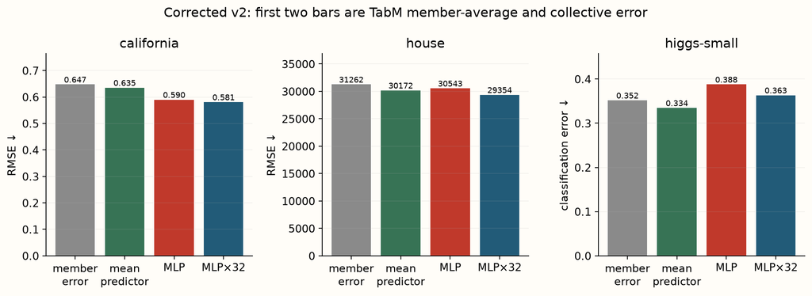

Corrected v2 author-reference measurement: compare collective and mean individual errors, then check the independent baselines. On narrow screens, scroll to read labels. Open full-size figure.

## 6. The k knob and submodel pruning

If complementary errors are the useful resource, more members are not automatically better. Changing k or pruning members probes how much additional diversity remains relative to its compute cost, motivating the controlled comparison that follows.

The k knob controls how many members you train. The paper's Figure 7 averages performance over 17 datasets, with five seeds per score, dropout 0.1, and a learning rate retuned for each k. Larger backbones tended to accommodate more members. Too high a k sometimes hurt, and width 64 or depth 1 was suboptimal in those studied middle-to-large regimes. This does not prove that every small TabM must fail, and it does not license comparing our fixed-learning-rate curves as if they replicated Figure 7. [§5.3](https://arxiv.org/html/2410.24210v3#S5.SS3), [D.7](https://arxiv.org/html/2410.24210v3#A4.SS7).

**Pruning is a different experiment.** Do not confuse choosing k with pruning members after training. Appendix D.6 greedily adds the next member that most improves the *current aggregate* on validation, starting from the best validation member. It stops when no new member helps *and* the current aggregate is already better than the original all-k validation result. Sorting members by standalone accuracy is a different algorithm, not this one. Section 5.2 reports 8.8±6.6 members retained out of 32 across 46 datasets, with slightly worse test performance. To actually save work you must prune the adapter rows and heads; merely averaging fewer already-computed outputs does not establish a speedup. We explain this published experiment but do not reproduce it here. [D.6](https://arxiv.org/html/2410.24210v3#A4.SS6).

### Increasing k changes both the estimator and the computation

There are two different experiments. Train separate models at k=1,4,16 and compare their final predictors; or train once at k=16 and evaluate subsets of its members. The first changes the training objective's coupled system and computational budget. The second studies the redundancy of a fixed trained ensemble. A pruning curve from the second is not a training-scaling curve from the first.

If you select a subset using validation performance, subset choice is another adaptive decision. Choosing the best subset on test labels would leak evaluation feedback. A fixed first-m-member rule is easy to reproduce but can be sensitive to member ordering; randomized subsets with saved seeds provide a clearer view of average subset behavior.

Measure time on the intended device. A larger batched member dimension can use hardware more efficiently even while doing more arithmetic. Parameter counts alone cannot predict latency, and latency alone cannot describe peak activation memory. Report batch size, member count, precision and whether timing includes preprocessing.

### Read weak members without dismissing the ensemble

Compare each member's loss with the aggregate loss and inspect paired error dependence. If members are individually weaker than standalone MLPs but their average is competitive, that is compatible with the method's purpose. It does not establish that weakness caused diversity or that any weak model would help.

A useful follow-up fixes the trained outputs and changes only aggregation or subset size. Another retrains under a fixed total compute budget. Keep these questions separate in the exit report, then state which evidence supports a practical choice of k.

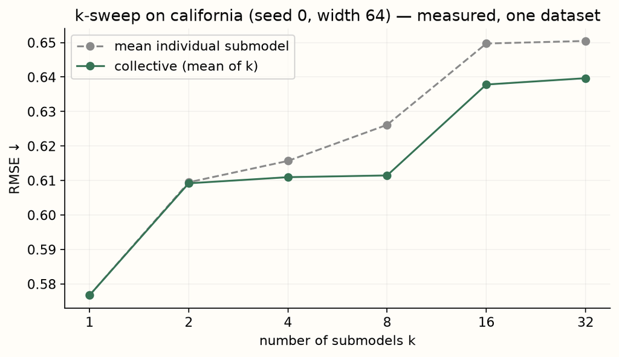

Corrected v2 author-reference k-sweep on California: inspect the shape; fixed learning rate and one seed do not reproduce the paper sweep. On narrow screens, scroll to read labels. Open full-size figure.

## 7. What exactly are we comparing?

**The four arms.** The corrected v2 suite compares four predictors: a single MLP, an independently checkpointed MLP×32, numeric TabM-mini with k=32, and a validation-tuned XGBoost. The California, House 16H and Higgs Small arrays come from the released TabR archive. Appendix C explicitly states that TabM inherits 38 TabR datasets, including these three, which is stronger provenance than matching dataset names alone. We keep those dataset boundaries but cap train/validation/test at 1200/600/600, using label-blind selection seeds 53/54/55.

**The fixed recipe.** Model seeds are 0/1/2. The neural arms use train-only median/z-score transforms, width 64, depth 3, dropout .1, Adam .002, 64 epochs, and batch 256 with the incomplete final batch dropped, and they take the **first strictly best validation checkpoint**. The deep ensemble selects each member independently. TabM uses shared batches and collective validation. XGBoost searches six depth/rate candidates, with 150-tree ceilings and validation stopping. These arms share equal data and metric boundaries; they do not share equal tuning or compute budgets.

**Scope check.** The small suite deliberately preserves the earlier budget to evaluate the corrected model without adding more training. It also fixes the checkpoint tie policy from last-best to first-best, which can change classifier scores; the v1/v2 difference is not a controlled estimate of initialization alone. It omits the paper's AdamW/clip1/patience16 procedure, usual modified quantile preprocessing, separately tuned neural recipes, feature embeddings, mostly 15 evaluation seeds, and 43 other datasets. The post-EXIT trainer adds independent member batches, normal quantiles, AdamW, gradient clipping and patience stopping in a separate track. Neither is a benchmark reproduction. We have not independently byte-compared a second TabM archive.

**What we record.** We save source hashes, exact selected row indices, raw array hashes, versions, predictions, plus single-MLP/TabM validation histories and selected epochs for v2. The independent deep ensemble saves aggregate predictions but does not retain every member checkpoint.

**Scope check.** The original v1 operators/results remain immutable historical evidence; their extra S₁, member biases and incorrect fan-in make those scores **not measurements of the corrected mini architecture**. Use each result with its own operator.

### PROVIDED · fit preprocessing on training rows

Z-score parameters are fixed before validation/test transformation. The shared target scaling and raw tree inputs come from the declared data loader.

```python
def _standardise(x):
    """Fit z-score on training rows only (plain preprocessing for MLP/TabM)."""
    mean = x['train'].mean(0, keepdims=True)
    std = x['train'].std(0, keepdims=True)
    std = np.where(std > 0, std, 1.)
    return {s: ((v - mean) / std).astype('float32') for s, v in x.items()}
```

### PROVIDED · independent MLP training and selection

Read the epoch loop: each MLP gets its own optimizer and first strictly best validation checkpoint. The deep ensemble then averages those separately chosen predictions; it is not TabM-packed.

```python
def _fit_one_mlp(data, xs, ys, seed, width, depth, epochs, lr, dropout, device='cpu'):
    """Train one plain MLP; return its best-epoch state and validation error."""
    torch.manual_seed(seed)
    regression = data['regression']
    model = MLP(xs['train'].shape[1], width=width, depth=depth,
                dropout=dropout, regression=regression).to(device)
    opt = torch.optim.Adam(model.parameters(), lr=lr, weight_decay=0.)
    loader = DataLoader(TensorDataset(xs['train'], ys['train']),
                        batch_size=min(256, len(xs['train'])), shuffle=True, drop_last=True)
    best, best_state, history = float('inf'), None, []
    for _ in range(epochs):
        model.train()
        for x, y in loader:
            out = model(x)
            loss = nn.functional.mse_loss(out[:, 0], y) if regression \
                else nn.functional.cross_entropy(out, y)
            opt.zero_grad(); loss.backward(); opt.step()
        model.eval()
        with torch.no_grad():
            p = model(xs['val'])
            p = p[:, 0].cpu().numpy() if regression else p.softmax(-1).cpu().numpy()
        e = error(p, data['y']['val'], regression, data['target_std'])
        history.append(e)
        if e < best:
            best, best_state = e, copy.deepcopy(model.state_dict())
    model.load_state_dict(best_state)
    return model, history

def _test_pred(model, xs, regression):
    model.eval()
    with torch.no_grad():
        p = model(xs['test'])
        return p[:, 0].cpu().numpy() if regression else p.softmax(-1).cpu().numpy()

def fit_mlp(data, xs, ys, seed, **hp):
    start = time.perf_counter()
    model, history = _fit_one_mlp(data, xs, ys, seed, **hp)
    p = _test_pred(model, xs, data['regression'])
    return dict(seed=seed, error=error(p, data['y']['test'], data['regression'], data['target_std']),
                prediction=p.tolist(), history=history, best_epoch=int(np.argmin(history)) + 1, parameters=sum(p.numel() for p in model.parameters()), seconds=time.perf_counter() - start)

def fit_deep_ensemble(data, xs, ys, seed, members=32, **hp):
    """MLP^{×k}: train `members` independent MLPs, average their test predictions."""
    start = time.perf_counter(); reg = data['regression']; preds = []
    for i in range(members):
        model, _ = _fit_one_mlp(data, xs, ys, seed * 1000 + i, **hp)
        preds.append(_test_pred(model, xs, reg))
    mean = np.mean(preds, axis=0)
    return dict(seed=seed, error=error(mean, data['y']['test'], reg, data['target_std']),
                prediction=mean.tolist(), members=members, seconds=time.perf_counter() - start)
```

### PROVIDED · jointly train the shared ensemble

This fitter calls your loss through `model.member_losses`, selects on collective validation error, and stores individual/collective test predictions for interpretation. All members share the current batch in this small track.

```python
def fit_tabm(data, xs, ys, seed, k=32, width=64, depth=3, epochs=64, lr=2e-3,
             dropout=.1, arch='mini', device='cpu'):
    """One TabM; record collective and mean-individual test errors (diversity)."""
    start = time.perf_counter(); torch.manual_seed(seed); reg = data['regression']
    model = TabM(xs['train'].shape[1], k=k, width=width, depth=depth, dropout=dropout,
                 regression=reg, arch=arch, seed=seed).to(device)
    opt = torch.optim.Adam(model.parameters(), lr=lr, weight_decay=0.)
    loader = DataLoader(TensorDataset(xs['train'], ys['train']),
                        batch_size=min(256, len(xs['train'])), shuffle=True, drop_last=True)
    best, best_state, history = float('inf'), None, []
    for _ in range(epochs):
        model.train()
        for x, y in loader:
            loss = model.member_losses(x, y)
            if not torch.isfinite(loss):
                raise RuntimeError('Nonfinite training loss')
            opt.zero_grad(); loss.backward(); opt.step()
        model.eval()
        with torch.no_grad():
            p = model.predict(xs['val']).cpu().numpy()
        e = error(p, data['y']['val'], reg, data['target_std']); history.append(e)
        if e < best:
            best, best_state = e, copy.deepcopy(model.state_dict())
    model.load_state_dict(best_state)
    model.eval()
    with torch.no_grad():
        collective = model.predict(xs['test']).cpu().numpy()
        members = model.member_predictions(xs['test']).cpu().numpy()   # [B,k] or [B,k,C]
    coll_err = error(collective, data['y']['test'], reg, data['target_std'])
    ind_errs = [error(members[:, i], data['y']['test'], reg, data['target_std'])
                for i in range(k)]
    return dict(seed=seed, error=coll_err, best_epoch=int(np.argmin(history)) + 1,
                individual_mean=float(np.mean(ind_errs)), individual_sd=float(np.std(ind_errs)),
                individual_best=float(np.min(ind_errs)), prediction=collective.tolist(), member_predictions=members.tolist(), history=history, parameters=sum(p.numel() for p in model.parameters()), seconds=time.perf_counter() - start)
```

### PROVIDED · compare procedures on identical selected rows

The suite reuses task boundaries, repeats seeds within each task, and only then ranks dataset-level mean errors. Neural recipes are fixed; XGBoost uses validation search, so this does not isolate architecture under equal tuning compute.

```python
def run_suite(names=('california', 'house', 'higgs-small'), seeds=(0, 1, 2),
              k=32, width=64, depth=3, epochs=64, lr=2e-3, dropout=.1,
              train_cap=1200, eval_cap=600, trees=150, candidates=6,
              device='cpu', data_root='data/cache/l052'):
    start = time.perf_counter(); torch.set_num_threads(1)
    arms = ['MLP', 'MLP-xk', 'TabM-mini', 'XGB-tuned']
    hp = dict(width=width, depth=depth, epochs=epochs, lr=lr, dropout=dropout)
    result = dict(config=dict(k=k, train_cap=train_cap, eval_cap=eval_cap, **hp,
                              trees=trees, candidates=candidates, seeds=list(seeds),
                              selection_seeds=[53, 54, 55], device=device),
                  versions={p: importlib.metadata.version(p)
                            for p in ['torch', 'numpy', 'scipy', 'scikit-learn', 'xgboost']},
                  results={}, verdict='INCOMPARABLE')
    with threadpool_limits(limits=1):
        for name in names:
            data = load_task(name, train_cap, eval_cap, data_root)
            xr = _standardise(data['raw'])
            xs = {s: torch.as_tensor(v, device=device) for s, v in xr.items()}
            ys = {s: torch.as_tensor(data['y'][s],
                                     dtype=torch.float32 if data['regression'] else torch.long,
                                     device=device) for s in xr}
            runs = {a: [] for a in arms}
            for seed in seeds:
                runs['MLP'].append(fit_mlp(data, xs, ys, seed, device=device, **hp))
                runs['MLP-xk'].append(fit_deep_ensemble(data, xs, ys, seed, members=k, device=device, **hp))
                runs['TabM-mini'].append(fit_tabm(data, xs, ys, seed, k=k, arch='mini',
                                                  width=width, depth=depth, epochs=epochs,
                                                  lr=lr, dropout=dropout, device=device))
                runs['XGB-tuned'].append(fit_trees(data, seed, trees, candidates)['XGB-tuned'])
                print(name, seed, {a: round(runs[a][-1]['error'], 5) for a in arms}, flush=True)
            result['results'][name] = dict(
                metric='RMSE' if data['regression'] else 'classification error',
                runs=runs, summary={a: seed_interval([r['error'] for r in runs[a]]) for a in arms},
                diversity=seed_interval([r['individual_mean'] for r in runs['TabM-mini']]),
                selection=data['selection'], hashes=data['hashes'], target_std=data['target_std'])
    means = np.array([[result['results'][n]['summary'][a]['mean'] for a in arms] for n in names])
    ranks = np.array([rankdata(row) for row in means]); test = friedmanchisquare(*means.T)
    cd = float(studentized_range.ppf(.95, len(arms), np.inf) / np.sqrt(2)
               * np.sqrt(len(arms) * (len(arms) + 1) / (6 * len(names))))
    result['ranks'] = dict(arms=arms, per_dataset=ranks.tolist(),
                           means=dict(zip(arms, ranks.mean(0).tolist())),
                           friedman_stat=float(test.statistic), friedman_p=float(test.pvalue),
                           nemenyi_cd=cd)
    result['elapsed_seconds'] = time.perf_counter() - start
    return result
```

### Read the selection boundary before training

`fit_tabm` selects its first strictly best checkpoint on the *ensemble's* validation error and records each submodel's individual test error alongside the collective error. `fit_deep_ensemble` trains k independent MLPs and averages them. `fit_trees` (from L053) selects one of six XGBoost candidates on validation, then scores on test. Predict which arm leads on each task before running. No CHECK requires a particular winner.

```python
# PROVIDED — live local experiment (lighter than author evidence: 3 seeds, k=8)
live_results = run_suite(seeds=(0,1,2), k=8, epochs=32)
rows = []
for name, data in live_results['results'].items():
    for arm, s in data['summary'].items():
        rows.append(dict(dataset=name, method=arm, metric=data['metric'], mean=s['mean'], sd=s['sd']))
    rows.append(dict(dataset=name, method='TabM submodel (mean)', metric=data['metric'],
                     mean=data['diversity']['mean'], sd=data['diversity']['sd']))
display(pd.DataFrame(rows))
display(pd.DataFrame([live_results['ranks']['means']]).T.rename(columns={0: 'mean rank'}))
print('Friedman p', live_results['ranks']['friedman_p'], 'CD', live_results['ranks']['nemenyi_cd'])
```

```python
# CHECK — record an empirical ordering; classification error need not improve
for name, data in live_results['results'].items():
    collective = data['summary']['TabM-mini']['mean']
    individual = data['diversity']['mean']
    assert np.isfinite([collective, individual]).all()
    print(f'{name}: collective {collective:.4f}; mean individual {individual:.4f}')
    if data['metric'] == 'RMSE':
        assert collective <= individual + 1e-6, 'RMSE norm convexity or aggregation implementation failed'
print('Interpret Higgs ordering from the observed probabilities, not a required winner.')
```

## 8. Read the evidence without importing a story

Here is the corrected v2 result, at k=32 and 64 epochs, over three seeds. California has the lowest mean error for XGB-tuned. House has the lowest mean error for MLP-xk. Higgs-small has the lowest mean error for XGB-tuned. The mean ranks are MLP 3.333, MLP-xk 2.000, TabM-mini 2.667, and XGB-tuned 2.000. The exploratory Friedman p=0.5319. In the table below, each cell shows mean ± sample SD, and the last column averages errors over individual members and seeds. This is a local protocol result, not the paper benchmark.

Scroll horizontally to compare all models.

| Task / error ↓ | MLP | MLP×32 | TabM-mini | XGB-tuned | Mean submodel |
| --- | --- | --- | --- | --- | --- |
| california / RMSE | 0.590 ± 0.005 | 0.581 ± 0.001 | 0.635 ± 0.005 | 0.520 ± 0.003 | 0.647 |
| house / RMSE | 30543 ± 1034 | 29354 ± 64 | 30172 ± 138 | 31521 ± 1072 | 31262 |
| higgs-small / classification error | 0.388 ± 0.018 | 0.363 ± 0.005 | 0.334 ± 0.006 | 0.323 ± 0.008 | 0.352 |

**How to read the table.** For regression, RMSE is in each task's own target units; for Higgs, the classification error is the fraction of wrong argmax predictions. Because the units differ, never average California RMSE with House RMSE. Instead, rank the four seed means separately within each dataset, then average those ranks across the three datasets. And remember that the seeds are repeats within a task, not nine independent benchmark tasks.

**Three artifacts, three questions.** Use the corrected v2 results, the pinned source parity report and the reproduction contract together. Code parity validates a mechanism. Validation selection defines a procedure. A published-result reproduction needs the paper's dataset, metric and selection protocol as well.

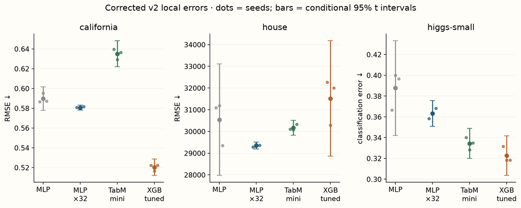

Corrected v2 author-reference local measurement (k=32, 3 seeds), separate from your lighter live run above. On narrow screens, scroll to read labels. Open full-size figure.

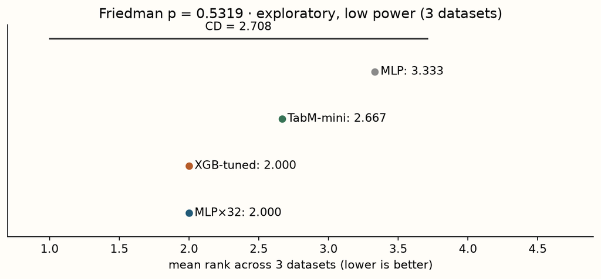

Corrected v2 author-reference ranks across three tasks. A low-power test is not evidence of equivalence. On narrow screens, scroll to read labels. Open full-size figure.

### EXIT TICKET · complete in your own words

Report one task's four arm errors with seed uncertainty, plus TabM's collective and mean-individual error. Using the variance formula σ²(ρ + (1−ρ)/k), explain why the collective can beat the individuals and why more k stops helping. State the paper verdict and two protocol deviations from the benchmark. Name one change (width, rows, embeddings, temporal splits) that would move this regime toward the paper's.

Paste your output and explanation to the teacher for feedback; passing numerical CHECKs alone does not grade the explanation.

```python
# EXIT — replace the blank explanation before submitting
interpretation = ""  # TODO: write your own conclusion and protocol limits
print('Paper verdict:', live_results['verdict'])
print('Dataset count:', len(live_results['results']))
print('Mean ranks:', live_results['ranks']['means'])
print('Your explanation:', interpretation or 'WRITE YOUR INTERPRETATION BEFORE SUBMITTING')
exit_artifact = dict(track='live-v2-k8-32epochs', results=live_results,
                     interpretation=interpretation, learner_complete=bool(interpretation.strip()))
exit_path = LABS / 'artifacts/l054/exit.json'; exit_path.parent.mkdir(parents=True, exist_ok=True)
exit_path.write_text(json.dumps(exit_artifact, indent=1))
print('Saved', exit_path, '— an empty interpretation remains incomplete.')
```

### NEXT STEP · a closer procedure, with live student functions

The small suite holds its historical budget fixed while correcting the model and checkpoint tie policy; it does not isolate initialization as the sole cause of a changed score. This separate trainer moves toward paper §3.4 and Appendix D.2: independently shuffled complete batches per member, train-only normal quantiles, AdamW, global gradient clipping at 1, and validation patience 16. It includes the last partial batch. Read how the row/member axes of inputs and targets are paired.

`closer` uses 6,000 California training rows, full released validation/test, width 256, k=32, 150-epoch ceiling and three seeds. `paper` increases to full training rows, width 512, 1,000-epoch ceiling and 15 seeds; it still uses a fixed recipe and unmodified sklearn quantiles, so **neither preset reproduces the tuned 46-task benchmark**. Numerical feature embeddings are absent. A smoke test validates execution only. The live code/data/environment identity is checked before resuming completed seeds.

Both this gated Colab path and the Modal operator are supplied. Larger runs and cloud execution are not implied by the existence of the scripts.

```python
# PROVIDED — the closer procedure, visible and used by the gate
from sklearn.preprocessing import QuantileTransformer
def fit_closer(data, seed, width, k, epochs, batch_size, device='cpu', model_class=None,
               loss_fn=None, predict_fn=None):
    """App D.2 and §3.4: each member receives a full independently shuffled batch."""
    model_class=TabM if model_class is None else model_class
    loss_fn=member_mean_loss if loss_fn is None else loss_fn
    predict_fn=ensemble_predict if predict_fn is None else predict_fn
    torch.manual_seed(seed);reg=data['regression']
    # Approximate paper default; released modified quantile/noise is not matched.
    transform=QuantileTransformer(n_quantiles=min(1000,len(data['raw']['train'])),
        output_distribution='normal',subsample=None,random_state=seed).fit(data['raw']['train'])
    x={s:torch.tensor(transform.transform(v),dtype=torch.float32,device=device) for s,v in data['raw'].items()}
    y={s:torch.tensor(v,dtype=torch.float32 if reg else torch.long,device=device) for s,v in data['y'].items()}
    model=model_class(x['train'].shape[1],k=k,width=width,depth=3,dropout=.1,regression=reg,arch='mini',seed=seed).to(device)
    opt=torch.optim.AdamW(model.parameters(),lr=.002,weight_decay=0.)
    best=float('inf');state=None;best_epoch=0;history=[];start=time.perf_counter()
    for epoch in range(epochs):
        model.train()
        permutations=torch.stack([torch.randperm(len(x['train']),device=device) for _ in range(k)],dim=1)
        for idx in permutations.split(batch_size):
            out=model(x['train'][idx])              # [B,k,d_y], targets [B,k]
            # Flatten BOTH in row-major order, preserving each output/target pair.
            loss=loss_fn(out.reshape(-1,1,out.shape[-1]),y['train'][idx].reshape(-1),reg)
            if not torch.isfinite(loss):raise RuntimeError('Nonfinite member loss')
            opt.zero_grad();loss.backward();torch.nn.utils.clip_grad_norm_(model.parameters(),1.);opt.step()
        model.eval()
        with torch.no_grad():
            p=torch.cat([predict_fn(model(b),reg) for b in x['val'].split(256)]).cpu().numpy()
        score=error(p,data['y']['val'],reg,data['target_std']);history.append(score)
        if score<best:best=score;best_epoch=epoch+1;state=copy.deepcopy(model.state_dict())
        if epoch+1-best_epoch>=16:break
    model.load_state_dict(state);model.eval()
    with torch.no_grad():p=torch.cat([predict_fn(model(b),reg) for b in x['test'].split(256)]).cpu().numpy()
    return dict(seed=seed,error=error(p,data['y']['test'],reg,data['target_std']),prediction=p.tolist(),
        best_epoch=best_epoch,history=history,epochs_run=len(history),seconds=time.perf_counter()-start,
        parameters=sum(p.numel() for p in model.parameters()))
```

```python
# NEXT STEP — opt in after EXIT (GPU recommended for closer)
RUN_PAPER_REPRO = False
if RUN_PAPER_REPRO:
    from _paper_repro_l054 import reproduce
    closer = reproduce('closer', out=LABS/'artifacts/l054/colab-closer',
        device='cuda' if torch.cuda.is_available() else 'cpu',
        model_class=TabM, loss_fn=member_mean_loss, predict_fn=ensemble_predict, runner=fit_closer)
    print(closer['summary']); print(closer['ledger'])
else:
    print('Closer run NOT_RUN by this gate; paper benchmark NOT_REPRODUCED.')
```

## 10. What the paper establishes, and what comes next

Figure 3 reports strong TabM-family performance across tabular deep learning on 46 tasks: 37 random splits and 9 domain-aware splits. Its relative-performance panels use accuracy or AUROC, or R² relative to MLP; they are not mean raw RMSE. Appendix D.3 ranks models in tiers using means and seed SDs, whereas our local chart uses ordinary ranks. When comparing a particular score, keep the paper's numeric, † embedding and ensemble variants separate. [§4.2](https://arxiv.org/html/2410.24210v3#S4.SS2).

Figure 4 times selected configurations. The asterisk-marked TabM variants additionally use mixed precision and torch.compile, and the authors explicitly caution against a direct unqualified efficiency comparison with unoptimized baselines. Table 2 evaluates full Maps Routing (6.5M rows) and Weather (13M), reusing configurations selected on smaller training sets with the same validation/test boundaries; most models use three seeds, and FT-Transformer uses one. TabR runs out of memory in that setup. That is measured applicability on those datasets and that hardware, not a theorem that retrieval can never scale. [§4.3](https://arxiv.org/html/2410.24210v3#S4.SS3), [D.4](https://arxiv.org/html/2410.24210v3#A4.SS4).

**A concrete future target.** Appendix E, Table 18 reports California numeric TabM-mini at RMSE **0.4479 ± 0.0022** for a single model, which itself contains k=32 branches. Its separate ensemble column averages five independently trained whole models and reports 0.4461 ± 0.0011. The † mini uses feature embeddings and reports 0.4275 ± 0.0024, so it is a different target. These are cited seed means and SDs under the paper procedure, not a tolerance for declaring our capped fixed recipe reproduced. [Table 18](https://arxiv.org/html/2410.24210v3#A5.T18).

### Connect the mechanism to the nearest alternatives

RealMLP (L053) changes the parameterization, preprocessing and optimization recipe of a single predictor. TabM instead changes how several prediction branches share parameters. The two ideas are potentially complementary, but combining them would be a new experiment. FT-Transformer (L050) lets columns exchange information through attention within each row. TabM's dense W mixes feature coordinates while its member axis stays separate; attention across members would alter its intended objective and branches.

TabR (L052) conditions a row on retrieved training examples and their labels at prediction time. TabM conditions only on a fixed fitted set of weights, with no runtime label memory. For a customer-churn table, all TabM branches still see the same engineered history columns, so more members cannot reveal the customer's unjoined service events. That is why a strong TabM baseline matters to the relational thesis without answering it. An eventual relational comparison must give both models legal information under the same prediction cutoff.

That sets up L055. Keep the ensemble, but change the *evaluation question*: does its ranking survive when training customers precede test customers in time, with labels available only after a delay? A random-split ensemble win and a temporal-split deployment win need separate evidence. Ask the teacher about any derivation, code path or result you cannot defend.

### Return tomorrow

Without reopening the formula, reconstruct the BatchEnsemble identity and explain which differences would be needed to test whether weight sharing or collective checkpointing helps an explicit ensemble. Then state what changes when a benchmark's split stops being random — the L055 question. Ask the teacher about any CHECK or derivation you cannot defend.